# Inteq R documentation

This R package estimates Volterra and Fredholm integral equations. It is a translation into R of the Python package “inteq” by Matthew W. Thomas (https://github.com/mwt/inteq).

# Fredholm integral equations

This package provides the function fredholm_solve which approximates the solution, $g(x)$, to the Fredholm Integral Equation of the first kind:

$$\begin{align}
f(s) = \int_a^b K(s, y)\, g(y)\, dy,
\end{align}$$

using the method described in Twomey (1963). It will return a grid that is an approximate solution, as demonstrated by the following example:

$$f(s) = \int_{-3}^{3} K(s, y)\, g(y)\, dy,$$

where the kernel $K(s, y)$ and left-hand side $f(s)$ are defined as:

$$K(s, y) =
\begin{cases}
1 + \cos\left(\dfrac{\pi (y - s)}{3}\right), & \text{if } |s - y|
\leq 3 \\
0, & \text{otherwise}
\end{cases},$$

$$f(s) = \frac{1}{2} \left[ (6 - |s|)\left(2 + \cos\left(\frac{|s|
\pi}{3}\right)\right) + \frac{9}{\pi} \sin\left(\frac{|s| \pi}{3}\right)
\right].$$

The true solution is $g(y) = K(0, y)$.

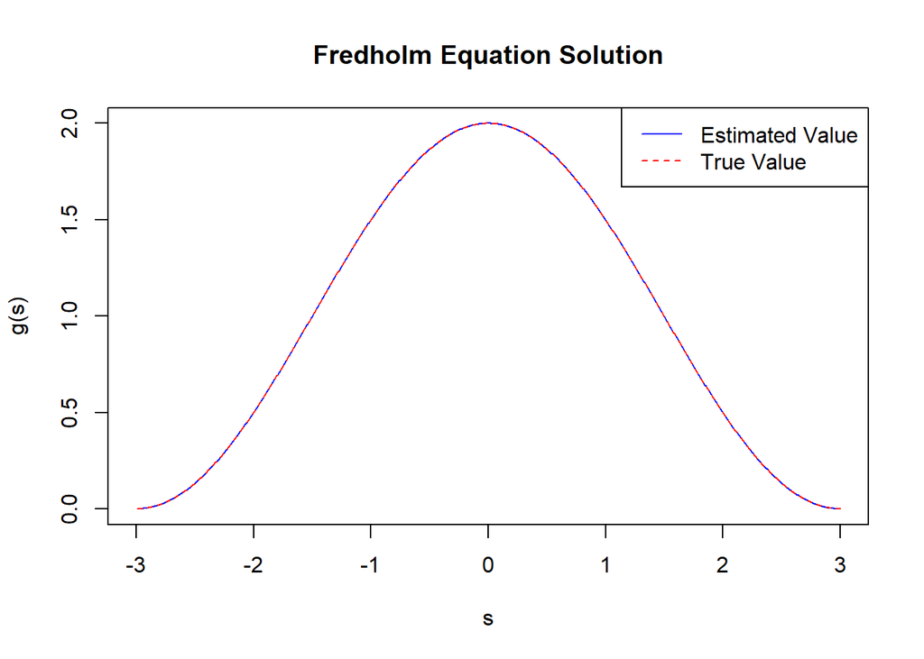

# Volterra integral equations

This package provides the function volterra_solve which approximates the solution, g(x), to the Volterra Integral Equation of the first kind:

$$\begin{align}
f(s) = \int_a^s K(s,y) g(y) dy,
\end{align}$$

using the method in Betto and Thomas (2021), as demonstrated by the following example:

$$f(s) = \int_0^s \cos(t-s) g(t) dt,$$

with left-hand side

$$f(s) = \int_0^s \cos(t-s) \frac{2 + t^2}{2} dt$$

and true solution

$$g(s) = \frac{2 + s^2}{2}.$$

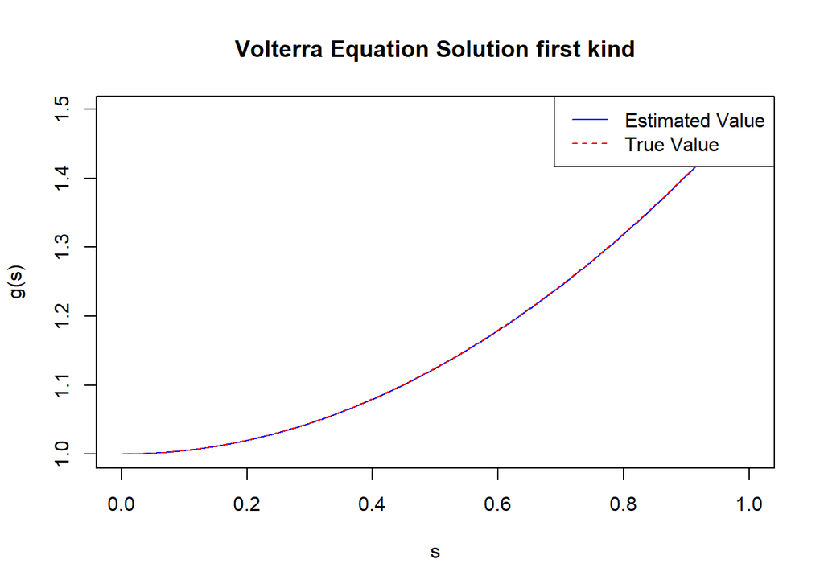

It also provides volterra_solve2 which approximates the solution, g(x), to the Volterra Integral Equation of the second kind:

$$\begin{align}
g(s) = f(s) + \int_a^s K(s,y) g(y) dy,
\end{align}$$

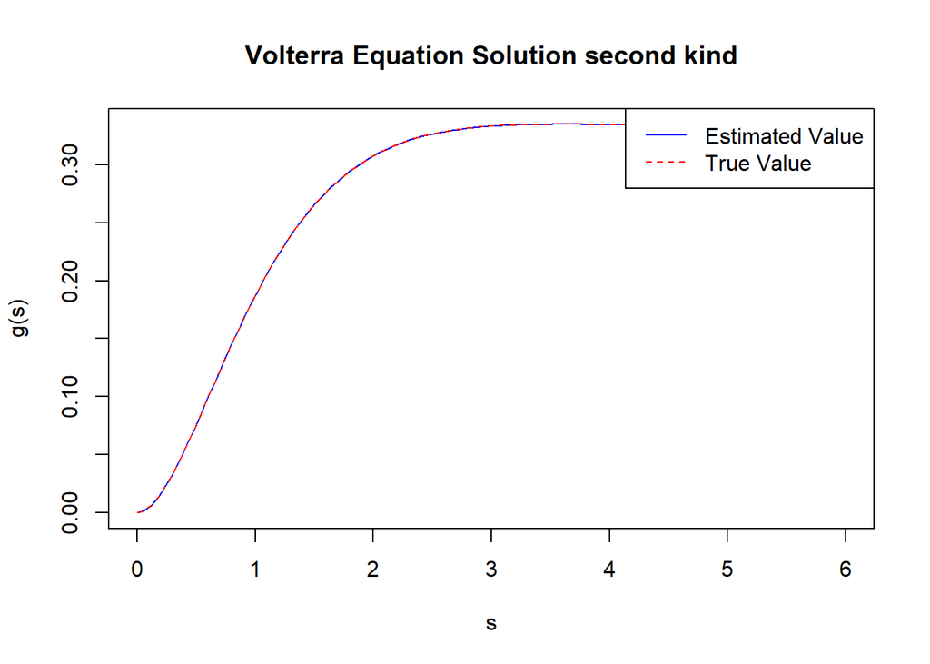